# Exploratory Data Analysis on the Indeed Dataset

## Data Source: [Indeed Dataset Kaggle](https://www.kaggle.com/elroyggj/indeed-dataset-data-scientistanalystengineer)

### About Indeed:

Indeed is an American worldwide employment-related search engine for job listings. This data is from indeed Job Postings related to Data Scientist/Analyst/Engineer in the United States.

#### In this workbook, the aim is to identify the market trends and required skills regarding jobs in Data Scientist/Analysis/Engineering.

```python
import pandas as pd
import matplotlib.pyplot as plt
```

```python
data= pd.read_csv('indeed_job_dataset.csv')
data.head()
```

|  | Unnamed: 0 | Job_Title | Link | Queried_Salary | Job_Type | Skill | No_of_Skills | Company | No_of_Reviews | No_of_Stars | ... | MD | DC | NC | Other_states | Consulting and Business Services | Internet and Software | Banks and Financial Services | Health Care | Insurance | Other_industries |
| --- | --- | --- | --- | --- | --- | --- | --- | --- | --- | --- | --- | --- | --- | --- | --- | --- | --- | --- | --- | --- | --- |
| 0 | 0 | Data Scientist | https://www.indeed.com/rc/clk?jk=6a105f495c36a... | <80000 | data_scientist | ['SAP', 'SQL'] | 2 | Express Scripts | 3301.0 | 3.3 | ... | 0 | 0 | 0 | 1 | 0 | 0 | 0 | 1 | 0 | 0 |
| 1 | 1 | Data Scientist | https://www.indeed.com/rc/clk?jk=86afd561ea8c6... | <80000 | data_scientist | ['Machine Learning', 'R', 'SAS', 'SQL', 'Python'] | 5 | Money Mart Financial Services | NaN | NaN | ... | 0 | 0 | 0 | 0 | 0 | 0 | 0 | 0 | 0 | 0 |
| 2 | 2 | Data Scientist | https://www.indeed.com/rc/clk?jk=e0aad317e6d45... | <80000 | data_scientist | ['Data Mining', 'Data Management', 'R', 'SAS',... | 9 | comScore | 62.0 | 3.5 | ... | 0 | 0 | 0 | 1 | 0 | 0 | 0 | 0 | 0 | 0 |
| 3 | 3 | Graduate Studies Program - Data Scientist | https://www.indeed.com/rc/clk?jk=1cfdd9e391a63... | <80000 | data_scientist | ['Certified Internal Auditor'] | 1 | Central Intelligence Agency | 158.0 | 4.3 | ... | 0 | 1 | 0 | 0 | 0 | 0 | 0 | 0 | 0 | 1 |
| 4 | 4 | Data Scientist I | https://www.indeed.com/rc/clk?jk=fec647775a21e... | <80000 | data_scientist | ['Statistical Software', 'Time Management', 'R... | 7 | Federal Reserve Bank of Dallas | 495.0 | 4.1 | ... | 0 | 0 | 0 | 0 | 0 | 0 | 1 | 0 | 0 | 0 |

5 rows × 43 columns

```python
data['Skill'].head(15)
```

```
0                                        ['SAP', 'SQL']
1     ['Machine Learning', 'R', 'SAS', 'SQL', 'Python']
2     ['Data Mining', 'Data Management', 'R', 'SAS',...
3                        ['Certified Internal Auditor']
4     ['Statistical Software', 'Time Management', 'R...
5     ['AI', 'Quantitative Analysis', 'Data Mining',...
6     ['Statistical Software', 'Machine Learning', '...
7                      ['Machine Learning', 'R', 'SQL']
8                     ['Linux', 'R', 'C/C++', 'Python']
9     ['JavaScript', 'Data Mining', 'TS/SCI Clearanc...
10    ['Machine Learning', 'R', 'SPSS', 'Data Analys...
11    ['Machine Learning', 'R', 'SPSS', 'Data Analys...
12    ['Machine Learning', 'Analysis Skills', 'Data ...
13                       ['Machine Learning', 'Python']
14    ['TensorFlow', 'Project Planning', 'Linux', 'M...
Name: Skill, dtype: object
```

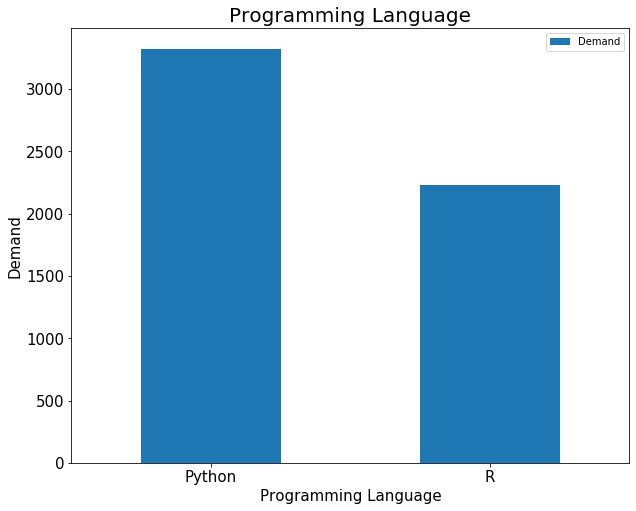

```python
python = data['python'].value_counts()[1]
r = data['r'].value_counts()[1]

languages = pd.DataFrame({'Programming Language':['Python','R'],'Demand':[python,r]})
languageplot = languages.plot.bar(x = 'Programming Language', y = 'Demand', figsize = (10,8), rot = 0 , fontsize = 15)
languageplot.set_ylabel('Demand', fontsize = 15)
languageplot.set_xlabel("Programming Language", fontsize = 15)
languageplot.set_title("Programming Language", fontsize = 20)
```

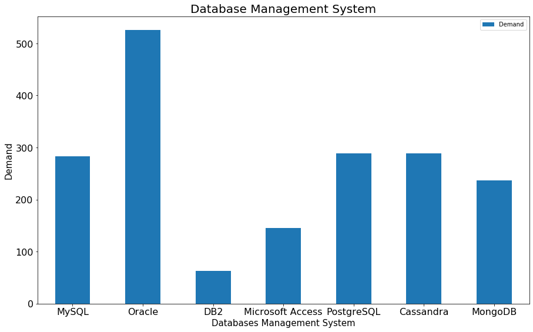

```python
mysql = data['Skill'].str.contains('MySQL').value_counts()[1]
oracle = data['Skill'].str.contains('Oracle').value_counts()[1]
db2 = data['Skill'].str.contains('DB2').value_counts()[1]
access = data['Skill'].str.contains('Microsoft Access').value_counts()[1]
postgre = data['Skill'].str.contains('PostgreSQL').value_counts()[1]
cassandra = data['Skill'].str.contains('Cassandra').value_counts()[1]
mongoDB =  data['Skill'].str.contains('MongoDB').value_counts()[1]

dbms = ['MySQL','Oracle','DB2','Microsoft Access','PostgreSQL','Cassandra','MongoDB']
dbms_demand = [mysql,oracle,db2,access,postgre,cassandra,mongoDB]
dbms_Data = pd.DataFrame({'DBMS':dbms, 'Demand':dbms_demand})
dbmsplot = dbms_Data.plot.bar(x = 'DBMS', y = 'Demand', figsize= (15,9), fontsize = 16, rot = 0)
dbmsplot.set_ylabel('Demand', fontsize = 15)
dbmsplot.set_xlabel("Databases Management System", fontsize = 15)
dbmsplot.set_title("Database Management System", fontsize = 20)
```

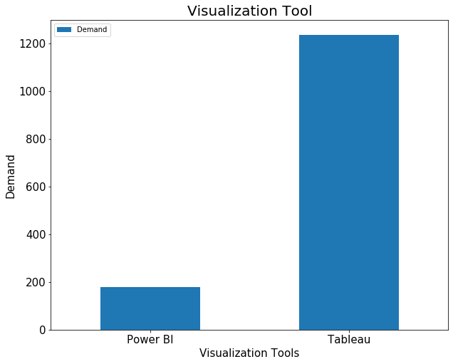

```python
power_bi = data['Skill'].str.contains('Power BI').value_counts()[1]
tableau = data['Skill'].str.contains('Tableau').value_counts()[1]

Visualization_Tools = ['Power BI','Tableau']
Visualization_Tools_demand = [power_bi,tableau]
Visualization_Tools_Data = pd.DataFrame({'Visualization Tools': Visualization_Tools,'Demand':Visualization_Tools_demand})
Visualizationplot = Visualization_Tools_Data.plot.bar(x = 'Visualization Tools',y ='Demand',rot = 0,figsize=(10,8), fontsize=15)
Visualizationplot.set_ylabel('Demand', fontsize = 15)
Visualizationplot.set_xlabel("Visualization Tools", fontsize = 15)
Visualizationplot.set_title("Visualization Tool", fontsize=20)
```

## PowerBI

Power BI is a collection of software services, apps, and connectors that work together to turn your unrelated sources of data into coherent, visually immersive, and interactive insights. Your data may be an Excel spreadsheet, or a collection of cloud-based and on-premises hybrid data warehouses. Power BI lets you easily connect to your data sources, visualize and discover what's important, and share that with anyone or everyone you want.

## Tableu

Tableau is a powerful and fastest growing data visualization tool used in the Business Intelligence Industry. It helps in simplifying raw data into the very easily understandable format. Data analysis is very fast with Tableau and the visualizations created are in the form of dashboards and worksheets. The data that is created using Tableau can be understood by professional at any level in an organization. It even allows a non-technical user to create a customized dashboard.The great thing about Tableau software is that it doesn't require any technical or any kind of programming skills to operate.

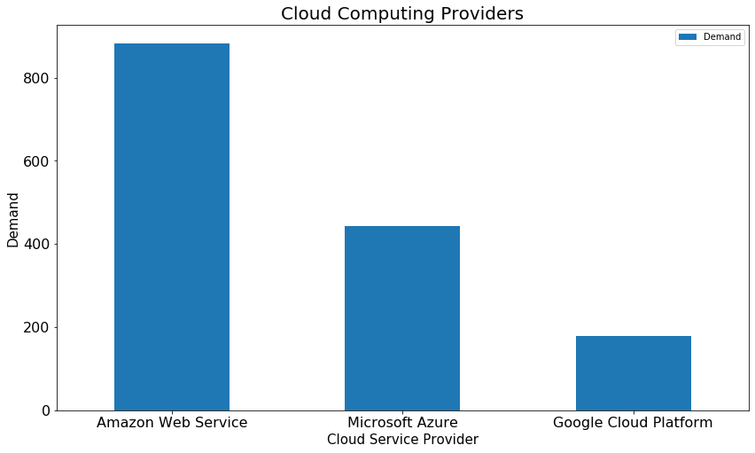

```python
aws = data['Skill'].str.contains('AWS').value_counts()[1]
azure = data['Skill'].str.contains('Azure').value_counts()[1]
gcp = data['Skill'].str.contains('Google Cloud').value_counts()[1]

cloud = ['Amazon Web Service', 'Microsoft Azure', 'Google Cloud Platform']
cloud_demand = [aws, azure, gcp]
cloud_Data = pd.DataFrame({'CloudServiceProvider': cloud , 'Demand': cloud_demand})
cloudplot = cloud_Data.plot.bar(x='CloudServiceProvider', y='Demand' , figsize=(14,8), rot=0, fontsize=16)
cloudplot.set_ylabel("Demand", fontsize=15)
cloudplot.set_xlabel("Cloud Service Provider", fontsize=15)
cloudplot.set_title("Cloud Computing Providers", fontsize=20)
```

[figure not shown]

```python
from IPython.display import Image

Image("img/Cloud And Data.PNG")
```

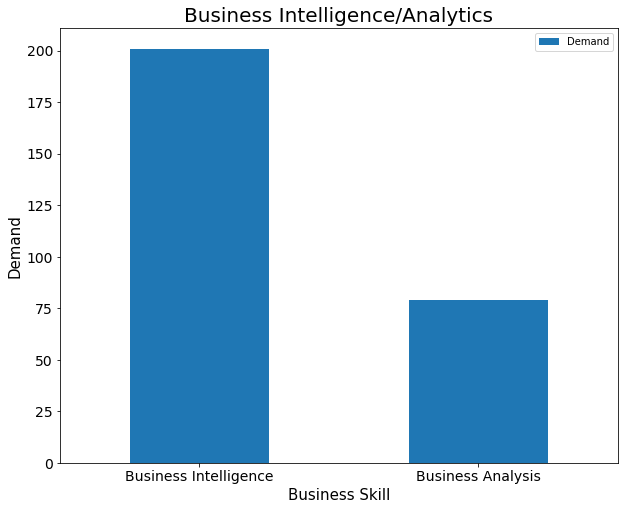

```python
Business_Intelligence = data['Skill'].str.contains('Business Intelligence').value_counts()[1]
Business_Analysis = data['Skill'].str.contains('Business Analysis').value_counts()[1]

BI_Skill = ['Business Intelligence','Business Analysis',]
BI_Skill_demand = [Business_Intelligence,Business_Analysis]
BI_Skill_Data = pd.DataFrame({'BI Skill': BI_Skill,'Demand':BI_Skill_demand})
Businessplot = BI_Skill_Data.plot.bar(x='BI Skill',y='Demand', rot=0 , figsize=(10,8), fontsize=14)
Businessplot.set_ylabel("Demand", fontsize=15)
Businessplot.set_xlabel("Business Skill", fontsize=15)
Businessplot.set_title("Business Intelligence/Analytics", fontsize=20)
```

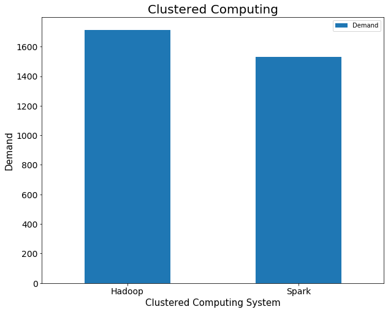

```python
hadoop = data['Skill'].str.contains('Hadoop').value_counts()[1]
Apache_Spark = data['Skill'].str.contains('Spark').value_counts()[1]

Distributed_Sys=['Hadoop','Spark',]
Distributed_Sys_demand=[hadoop,Apache_Spark]
Distributed_Sys_Data=pd.DataFrame({'Distributed Systems':Distributed_Sys,'Demand':Distributed_Sys_demand})
Distributedplot= Distributed_Sys_Data.plot.bar(x='Distributed Systems',y='Demand', rot=0 , figsize=(10,8), fontsize=14)
Distributedplot.set_ylabel("Demand", fontsize=15)
Distributedplot.set_xlabel("Clustered Computing System", fontsize=15)
Distributedplot.set_title("Clustered Computing", fontsize=20)
```

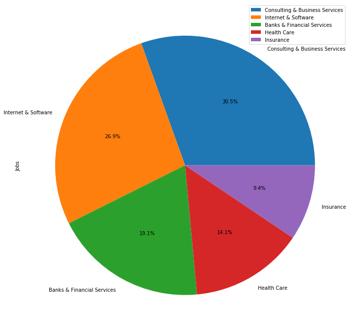

```python
consulting=data['Consulting and Business Services'].value_counts()[1]
internet=data['Internet and Software'].value_counts()[1]
bank=data['Banks and Financial Services'].value_counts()[1]
health=data['Health Care'].value_counts()[1]
insurance =data['Insurance'].value_counts()[1]

FIELDS=pd.DataFrame({"Jobs": [consulting,internet,bank,health,insurance]},
                            index=['Consulting & Business Services','Internet & Software', 'Banks & Financial Services','Health Care','Insurance'])
FIELDS.plot.pie(y="Jobs",figsize=(12,12),autopct="%1.1f%%")
```

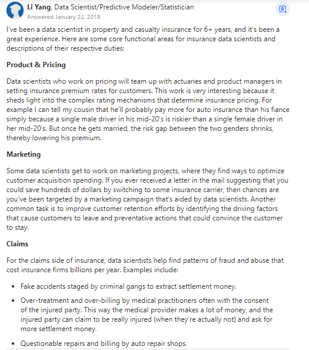

```python
from IPython.display import Image

Image("img/Capture.PNG")
```

[figure not shown]

```python
from IPython.display import Image

Image("img/Data-Science-in-Healthcare-1280x720.jpg")
```

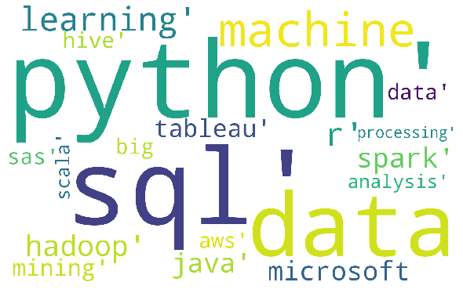

```python
from wordcloud import WordCloud, STOPWORDS
import matplotlib.pyplot as plt
import pandas as pd

df = pd.read_csv('indeed_job_dataset.csv')

comment_words = ''
stopwords = set(STOPWORDS)

for word in df.Skill:
    word = str(word)
    tokens = word.split()
    for i in range(len(tokens)):
        tokens[i] = tokens[i].lower()

    comment_words += " ".join(tokens)+" "

wordcloud = WordCloud(width=1600,height=1000, max_words=20,
                relative_scaling=0.5,
                background_color="white",
                stopwords = stopwords,
                min_font_size = 10,
                collocations=False).generate(comment_words)


plt.figure(figsize = (8, 8), facecolor = None)
plt.imshow(wordcloud)
plt.axis("off")
plt.tight_layout(pad = 0)

plt.show()
```

```python
wordcloud.to_file("wordcloud.png")
```

```
<wordcloud.wordcloud.WordCloud at 0x19895285fd0>
```

```python
ls
```

[output not shown]

## Conclusion:

1) Python is still the dominant programming language of choice but R is gaining popularity rapidly even though the first stable beta release of R was back in 2000 during which python had already released its second version the Python 2.0.

2) Oracle is the most popular Database Management System worldwide as of June 2020. Oracle also recently announced its Oracle Cloud Data Science Platform with features like: a) Python support for machine learning algorithms within the Oracle Autonomous Database that reduces the need to move data. b) New data catalog, to discover, find, organize, enrich and create data assets c) New big data service delivers a full Cloudera Hadoop implementation d) New service provides SQL access to HDFS and a new fully managed service to run Apache Spark applications

3) Tableau is one among the top Business Intelligence and Data Visualization tools available today. Most of the Fortune Global 500 companies are using this tool. In the Business Intelligence category, Tableau has a market spread of about 16.23% with 46,812 companies are using Tableau today. Source:[Why is Tableu so popular](https://www.knowledgehut.com/blog/business-intelligence-and-visualization/why-tableau-is-so-popular#:~:text=Tableau%20is%20one%20among%20the,companies%20are%20using%20Tableau%20today.)

3) All the three cloud servce providers have their strengths and weakness. The choice of the cloud vendor is of the employer and since AWS is widely used by most companies, it has a high demand in the job market.

4) Business intelligence focuses on descriptive analytics, business analytics focuses on predictive analytics. Consider an E-Commerce website, from a business intelligence perspective one would look at how people are using your website, identifying trends in traffic, analyzing visitor demographics, and maybe even creating a system for tracking how customers click through different pages(descriptive analysis). A business analyst would deal more with the practical applications of this data and how it helps you make decisions for purchasing ads, creating new products, and updating your website. Source:[Business Intelligence or Business Analytics](https://www.tableau.com/learn/articles/business-intelligence/bi-business-analytics)

5) Apache Hadoop is an open-source framework written in Java that allows us to store and process Big Data in a distributed environment across various clusters of computers. For this Hadoop uses an algorithm called MapReduce, which divides the task into small parts and assigns them to a set of computers. Hadoop also has its own file system, Hadoop Distributed File System (HDFS), which is based on Google File System (GFS). HDFS is designed to run on low-cost hardware.

6) Apache Spark is an open-source distributed cluster-computing framework. Spark is a data processing engine developed to provide faster and easy-to-use analytics than Hadoop MapReduce. Hadoop and Spark can be used together, Spark brings speed and Hadoop brings one of the most scalable and cheap storage systems which makes them work together.